# Your Digest for Tuesday, Apr 02, 2024 11:59 PM

# Q 9 : Diabetic ketoacidosis

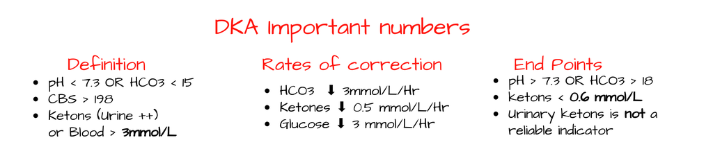

[output not shown]

[output not shown]

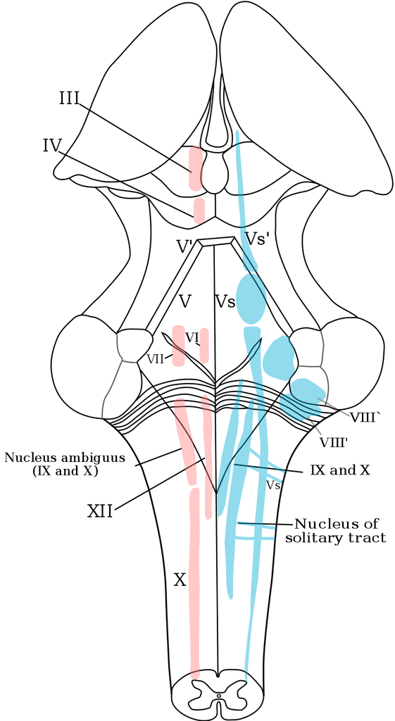

> [!TIP] Mnemonics:
> - Nucleus of tractus solitarius is a sensory nucleus. (**NTS** - *The S is for sensory*)
>   - "Nucleus of tractus sensarious"
>   - Receives afferents from the vagal nerve and tongue
> - Nucleus ambiguus is a motor nucleus which contains motor efferents to
>   - muscles of the soft palate and larynx and parasympathetic motor neurons to the heart.

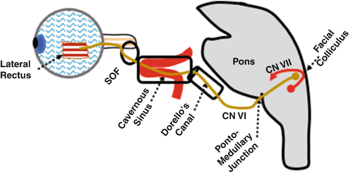

# Linezolid

- Similar spectrum to vancomycin.
- Used when there is vancomycin resistance.  
  [Source]([Linezolid: a review of its properties, function, and use in critical care - PMC](https://www.ncbi.nlm.nih.gov/pmc/articles/PMC6014438/))

- Cup : Disk ratio > 0.7 is seen.
- **Managementof** AACG - acetazolamide 500mg stat followed by pilocarpine (muscarinic agonist)
- POAG - primary open angle glaucoma - associated with myopia (long eye ball) and not hypermetropia (short eye ball) like AACG.
  - 360° **selective laser trabeculoplasty (SLT)** first-line to people with an IOP of ≥ 24 mmHg
  - Latanoprost (prostaglandin analogue) is a **first line drug** in POAG. It increases uveroscleral outflow.
  - Timolol (beta blocker) reduces production of aqueous humour. *Second line drug.*
  - Last line: Surgical trabeculoplasty

[figure not shown]

# Mastocytosis

> [!TIP] Mnemonic: A bit like carcinoid syndrome (flushing, diarrhoea) but mastocytosis has a rash.
- Abnormal accumulation of **mast cells** in tissues.
- Cutaneous mastocytosis - more in children.
  - Characteristic rash : urticaria pigmentosa. (aka Maculopapular cutaneous mastocytosis)
  - Blistering is seen exclusively in children.

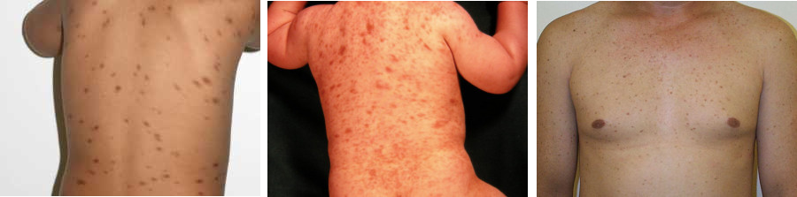

  - Doesn't require specific treatment *settles by teen years*.
  - However, predisposes to anaphylaxis with insect stings and severe reactions can cause fainting.
- Systemic mastocytosis - more in adults.
  - Mast cells accumulate in spleen, liver, bone marrow, lymphatics.
  - Symptoms: **flushing**, headache, dyspnea, wheezing, rhinorrhea, nausea, vomiting, **diarrhea**, and **syncope**.
  - #hepatosplenomegaly
- **Diagnosis**:
  - Urinary histamine levels
  - Serum tryptase (is not elevated in pure cutaneous mastocytosis) but is elevated in systemic mastocysosis.